# Task 7 - Critical Evaluation of Principal Component Analysis

Retail Product Demand Analysis at Fragceylon

IT3081 Statistical Modelling

21 September 2026

# 1 Task 7 Overview

Task 7 critically evaluates whether **Principal Component Analysis (PCA)** would be beneficial for the Fragceylon retail product demand dataset.

The assignment requires discussion of:

- whether dimensionality reduction is necessary;
- possible advantages of PCA;
- limitations;
- expected impact on predictive modelling;
- situations where PCA should and should not be used;
- research support for the final argument.

PCA is **not forced into the final modelling workflow** simply because it appears in the assignment.

The evaluation is based on two stages:

1. **Applicability audit of the original Fragceylon variables**
2. **Exploratory PCA and Principal Component Regression (PCR) sensitivity analysis**

The second stage uses the same current-regime modelling population and chronological train/test split used in Task 5 so that predictive performance can be compared fairly.

# 2 1. Why PCA Must Be Evaluated Before It Is Used

Principal Component Analysis transforms a set of correlated numerical variables into a smaller set of uncorrelated linear combinations called **principal components**.

PCA can be useful when:

- there are many numerical predictors;
- predictors are strongly correlated;
- dimensionality reduction is needed;
- model stability is affected by multicollinearity;
- retaining every original feature is unnecessary.

However, PCA is not automatically appropriate for every dataset.

For Fragceylon, the first question is therefore:

> **Does the current dataset actually contain enough suitable continuous predictors for PCA to provide meaningful dimensionality reduction?**

# 3 2. Load the Current Regular-Order Dataset

```r
regular_orders = read_excel(
  "04_Cleaned_Data/Fragceylon_Regular_Orders.xlsx"
)

regular_orders$Date = as.Date(
  regular_orders$Date
)

dim(
  regular_orders
)
```

```
## [1] 3116   22
```

```r
names(
  regular_orders
)
```

```
##  [1] "Order ID"          "Date"              "Product Name"
##  [4] "Product Code"      "Channel Type"      "Buyer"
##  [7] "Line Type"         "Quantity"          "Unit Price (LKR)"
## [10] "Total Value (LKR)" "Export Market"     "Outlier_IQR_Flag"
## [13] "Year"              "Month"             "Month_Number"
## [16] "Quarter"           "Day_of_Week"       "Year_Month"
## [19] "Time_Trend"        "Sales_Regime"      "Is_Regular_Order"
## [22] "Market_Group"
```

The analytical dataset contains:

- **3,116 Regular Order observations**
- **22 variables**

The response variable remains **Quantity**.

# 4 3. Numeric Variable Audit

A variable being stored as numeric in R does **not** automatically mean it is appropriate for PCA.

The Task 7 script therefore first audited all numeric variables.

```r
numeric_audit = read.csv(
  "08_Model_Results/R/Task7_Numeric_Variable_Audit.csv",
  stringsAsFactors = FALSE
)

kable(
  numeric_audit,
  caption = "Numeric Variable Audit"
)
```

Numeric Variable Audit

| Variable | Class | Unique_Values | Minimum | Maximum |
| --- | --- | --- | --- | --- |
| Quantity | numeric | 571 | 23.0 | 998 |
| Unit Price (LKR) | numeric | 6 | 330.6 | 450 |
| Total Value (LKR) | numeric | 904 | 9832.5 | 347304 |
| Year | numeric | 3 | 2024.0 | 2026 |
| Month_Number | numeric | 12 | 1.0 | 12 |
| Time_Trend | numeric | 474 | 0.0 | 620 |
| Is_Regular_Order | numeric | 1 | 1.0 | 1 |

## 4.1 Interpretation

The dataset contains several numeric variables, but many are unsuitable for standard PCA.

Examples include:

- `Quantity` - response variable;
- `Total Value (LKR)` - derived from Quantity × Unit Price;
- `Year` - time label;
- `Month_Number` - numeric coding of a cyclical category;
- `Is_Regular_Order` - constant in the Regular Order dataset;
- `Time_Trend` - meaningful numerical predictor.

Therefore, simply selecting every numeric column would be statistically inappropriate.

# 5 4. PCA Variable Suitability Audit

```r
pca_suitability = read.csv(
  "08_Model_Results/R/Task7_Variable_Suitability_Audit.csv",
  stringsAsFactors = FALSE
)

kable(
  pca_suitability,
  caption = "Suitability of Fragceylon Variables for Standard PCA"
)
```

Suitability of Fragceylon Variables for Standard PCA

| Variable | Analytical_Role | Suitable_For_Standard_PCA | Reason |
| --- | --- | --- | --- |
| Order ID | Identifier | No | Identifier has no continuous analytical meaning. |
| Date | Time identifier | No | Raw date is better represented by derived time features. |
| Product Name | Categorical predictor | No | Categorical variable; standard PCA is not designed for nominal labels. |
| Product Code | Product identifier | No | Redundant with Product Name and functions as an identifier. |
| Channel Type | Categorical predictor | No | Categorical and structurally confounded with business regime. |
| Buyer | High-cardinality categorical variable | No | Categorical with many levels and risk of memorizing buyers. |
| Line Type | Record-type variable | No | All rows in this analytical dataset are Regular Orders. |
| Quantity | Response | No | Quantity is the response to be predicted, not a predictor to compress. |
| Unit Price (LKR) | Numeric business variable | Cautious / not primary | Numeric, but follows business pricing rules and was excluded from the primary Task 5 predictor set. |
| Total Value (LKR) | Derived outcome/value variable | No | Contains Quantity through Quantity x Unit Price and would create target leakage. |
| Export Market | Categorical predictor | No | Categorical variable; dummy encoding is possible but reduces component interpretability. |
| Year | Derived time variable | No | Only a derived time label and not a rich continuous business measurement. |
| Month | Categorical time variable | No | Nominal/cyclical time category. |
| Month_Number | Numeric-coded month | No | The integers 1-12 are labels for a cyclical category, not an ordinary continuous measurement. |
| Quarter | Categorical time variable | No | Categorical time grouping. |
| Day_of_Week | Categorical time variable | No | Categorical cyclical variable. |
| Year_Month | Derived time label | No | Time label rather than an independent continuous measurement. |
| Time_Trend | Numeric time predictor | Yes | Meaningful numeric time index, but only one clean continuous predictor is insufficient for useful PCA. |
| Sales_Regime | Derived regime variable | No | Categorical regime indicator and constant in the current modelling regime. |
| Is_Regular_Order | Regular-order indicator | No | Constant because this dataset contains Regular Orders only. |
| Market_Group | Categorical market variable | No | Categorical/redundant representation of market. |
| Outlier_IQR_Flag | Response-derived diagnostic flag | No | Derived from Quantity and therefore unsuitable as a predictor. |

## 5.1 Main finding

After considering analytical meaning rather than storage type, **Time_Trend is the only clean continuous primary predictor clearly suitable for ordinary PCA**.

This means standard PCA on the original meaningful predictor set is not naturally useful because PCA needs multiple numerical variables in order to reduce dimensionality.

# 6 5. Why Important Variables Are Not Natural PCA Inputs

## 6.1 Product Name

`Product Name` is categorical.

The four products are business categories rather than points on a continuous numerical scale.

## 6.2 Export Market

`Export Market` is categorical.

Local and Japan are distinct categories rather than continuous values.

## 6.3 Month and Day of Week

Month and Day of Week are categorical and cyclical.

For example, December is not meaningfully “twelve times” January.

Treating month numbers directly as an ordinary continuous variable would be misleading.

## 6.4 Quantity

Quantity is the response being explained or predicted.

Including it in predictor PCA would mix the target with the predictors.

## 6.5 Total Value

Total Value is calculated from:

$$TotalValue = Quantity \times UnitPrice$$

Therefore it contains direct information about the response and would create **target leakage**.

## 6.6 Unit Price

Unit Price is genuinely numeric, but its values follow business pricing rules and were deliberately excluded from the main Task 5 generalizable predictor set.

# 7 6. Is Dimensionality Reduction Necessary?

The exploratory PCA stage used the same broader Task 5 predictor set:

- Product Name
- Export Market
- Month
- Day of Week
- Time Trend

Categorical variables were converted to dummy variables using `model.matrix()`.

```r
predictor_matrix_audit = read.csv(
  "08_Model_Results/R/Task7_PCA_Predictor_Matrix_Audit.csv",
  stringsAsFactors = FALSE
)

kable(
  predictor_matrix_audit,
  digits = 4,
  caption = "Encoded Predictor Matrix Audit"
)
```

Encoded Predictor Matrix Audit

| Measure | Value |
| --- | --- |
| Training observations | 1599.0000 |
| Encoded predictors before zero-variance removal | 22.0000 |
| Encoded predictors used for PCA | 22.0000 |
| Observation-to-predictor ratio | 72.6818 |
| Matrix rank | 22.0000 |
| Condition number of standardized matrix | 135.1427 |
| Maximum absolute pairwise correlation | 0.4136 |
| Number of absolute correlations >= 0.70 | 0.0000 |

## 7.1 Interpretation

The resulting modelling space contains:

- **1,599 training observations**
- **22 encoded predictors**
- observation-to-predictor ratio of approximately **72.68**

This is not a high-dimensional problem in which the number of predictors is close to or larger than the number of observations.

The matrix is also full rank.

The maximum absolute pairwise correlation is approximately **0.414**, and there are no predictor pairs with absolute correlation of at least 0.70.

Therefore, severe raw pairwise correlation is not a major reason to apply PCA.

# 8 7. Why an Exploratory PCA Was Still Performed

Although standard PCA is not naturally required by the original data structure, an exploratory PCA was performed for two reasons:

1. to quantify how much dimensionality reduction could actually be achieved;
2. to test whether PCA-based regression improves future holdout prediction.

This is a **sensitivity analysis**, not a recommendation to use PCA operationally.

The PCA model was fitted using the training data only.

This avoids test-data leakage.

# 9 8. Why Centering and Scaling Are Required

PCA is affected by the scale of input variables.

The encoded predictors include:

- binary dummy variables;
- numerical Time Trend.

Without standardization, Time Trend would dominate the PCA because its numerical range is much larger.

Therefore, the exploratory PCA used:

```r
prcomp(
  x_train,
  center = TRUE,
  scale. = TRUE
)
```

This places the variables on comparable standardized scales before component extraction.

# 10 9. Explained Variance

```r
pca_variance = read.csv(
  "08_Model_Results/R/Task7_PCA_Explained_Variance.csv",
  stringsAsFactors = FALSE
)

kable(
  head(
    pca_variance,
    22
  ),
  digits = 4,
  caption = "Explained Variance by Principal Component"
)
```

Explained Variance by Principal Component

| Principal_Component | Eigenvalue | Explained_Variance | Explained_Variance_Percent | Cumulative_Variance | Cumulative_Variance_Percent |
| --- | --- | --- | --- | --- | --- |
| PC1 | 1.6615 | 0.0755 | 7.5523 | 0.0755 | 7.5523 |
| PC2 | 1.4407 | 0.0655 | 6.5486 | 0.1410 | 14.1009 |
| PC3 | 1.3774 | 0.0626 | 6.2607 | 0.2036 | 20.3616 |
| PC4 | 1.3297 | 0.0604 | 6.0443 | 0.2641 | 26.4059 |
| PC5 | 1.2887 | 0.0586 | 5.8579 | 0.3226 | 32.2637 |
| PC6 | 1.2277 | 0.0558 | 5.5805 | 0.3784 | 37.8443 |
| PC7 | 1.2106 | 0.0550 | 5.5029 | 0.4335 | 43.3472 |
| PC8 | 1.1809 | 0.0537 | 5.3678 | 0.4871 | 48.7149 |
| PC9 | 1.1300 | 0.0514 | 5.1361 | 0.5385 | 53.8511 |
| PC10 | 1.0709 | 0.0487 | 4.8679 | 0.5872 | 58.7190 |
| PC11 | 1.0632 | 0.0483 | 4.8329 | 0.6355 | 63.5519 |
| PC12 | 1.0333 | 0.0470 | 4.6968 | 0.6825 | 68.2486 |
| PC13 | 1.0187 | 0.0463 | 4.6304 | 0.7288 | 72.8790 |
| PC14 | 1.0005 | 0.0455 | 4.5478 | 0.7743 | 77.4268 |
| PC15 | 0.9943 | 0.0452 | 4.5195 | 0.8195 | 81.9463 |
| PC16 | 0.9838 | 0.0447 | 4.4718 | 0.8642 | 86.4180 |
| PC17 | 0.9423 | 0.0428 | 4.2833 | 0.9070 | 90.7013 |
| PC18 | 0.9285 | 0.0422 | 4.2206 | 0.9492 | 94.9219 |
| PC19 | 0.6557 | 0.0298 | 2.9806 | 0.9790 | 97.9024 |
| PC20 | 0.2891 | 0.0131 | 1.3142 | 0.9922 | 99.2166 |
| PC21 | 0.1710 | 0.0078 | 0.7772 | 0.9999 | 99.9938 |
| PC22 | 0.0014 | 0.0001 | 0.0062 | 1.0000 | 100.0000 |

# 11 10. Scree Plot

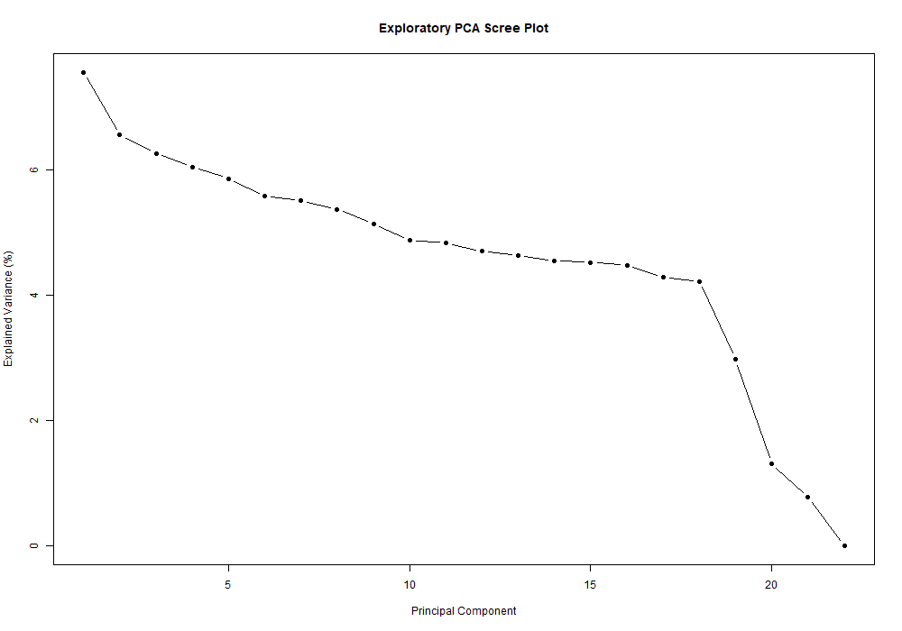

## 11.1 Interpretation

The scree plot shows that variance is spread across many components rather than being captured by only a small number of dominant components.

This is an important warning sign against using PCA as a major dimensionality-reduction tool in this dataset.

# 12 11. Cumulative Explained Variance

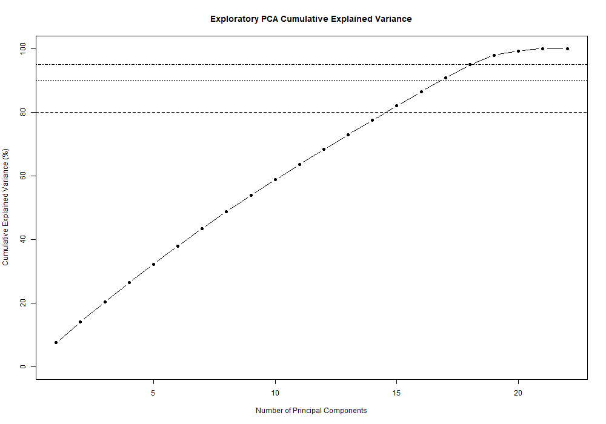

The number of components required at common variance thresholds is:

```r
variance_thresholds = read.csv(
  "08_Model_Results/R/Task7_PCA_Variance_Thresholds.csv",
  stringsAsFactors = FALSE
)

kable(
  variance_thresholds,
  digits = 2,
  caption = "Principal Components Required at Different Variance Thresholds"
)
```

Principal Components Required at Different Variance Thresholds

| Variance_Threshold | Components_Required | Original_Predictors | Reduction_Percent |
| --- | --- | --- | --- |
| 80% | 15 | 22 | 31.82 |
| 90% | 17 | 22 | 22.73 |
| 95% | 19 | 22 | 13.64 |

The results show:

- **80% variance requires 15 components**
- **90% variance requires 17 components**
- **95% variance requires 19 components**

The original encoded feature set contains only 22 predictors.

Therefore, retaining 95% of the predictor variance reduces:

$$22 \text{ predictors} \rightarrow 19 \text{ components}$$

Only three dimensions are removed.

This represents approximately:

$$\frac{22-19}{22} \times 100
\approx 13.6\%$$

dimensionality reduction.

That is a relatively small reduction compared with the loss of direct business interpretability.

# 13 12. PCA Loadings

The principal-component loadings indicate how strongly each original encoded predictor contributes to a component.

```r
pc1_loadings = read.csv(
  "08_Model_Results/R/Task7_PC1_Loadings_Ranked.csv",
  stringsAsFactors = FALSE
)

kable(
  head(
    pc1_loadings,
    10
  ),
  digits = 4,
  caption = "Largest Absolute Loadings for PC1"
)
```

Largest Absolute Loadings for PC1

| Variable | Loading | Absolute_Loading |
| --- | --- | --- |
| Time_Trend | 0.6813 | 0.6813 |
| MonthMarch | 0.3675 | 0.3675 |
| MonthJanuary | 0.3462 | 0.3462 |
| MonthMay | -0.3172 | 0.3172 |
| MonthJune | -0.1926 | 0.1926 |
| MonthFebruary | 0.1597 | 0.1597 |
| MonthAugust | -0.1351 | 0.1351 |
| MonthSeptember | -0.1300 | 0.1300 |
| Day_of_WeekSaturday | -0.1239 | 0.1239 |
| Day_of_WeekSunday | 0.1104 | 0.1104 |

PC1 is driven mainly by:

- Time Trend;
- March;
- January;
- May;
- other time-related dummy variables.

Therefore, PC1 primarily represents a complex mixture of time progression and calendar structure.

# 14 13. PC2 Loadings

```r
pc2_loadings = read.csv(
  "08_Model_Results/R/Task7_PC2_Loadings_Ranked.csv",
  stringsAsFactors = FALSE
)

kable(
  head(
    pc2_loadings,
    10
  ),
  digits = 4,
  caption = "Largest Absolute Loadings for PC2"
)
```

Largest Absolute Loadings for PC2

| Variable | Loading | Absolute_Loading |
| --- | --- | --- |
| `Product Name`Mesmerose | -0.7010 | 0.7010 |
| `Product Name`Kennedy | 0.6401 | 0.6401 |
| MonthDecember | 0.1317 | 0.1317 |
| MonthMarch | -0.1179 | 0.1179 |
| `Export Market`Japan | -0.0987 | 0.0987 |
| Day_of_WeekFriday | -0.0973 | 0.0973 |
| `Product Name`Secret Ambrosia | 0.0917 | 0.0917 |
| Day_of_WeekWednesday | 0.0858 | 0.0858 |
| MonthMay | -0.0848 | 0.0848 |
| MonthSeptember | 0.0787 | 0.0787 |

PC2 is dominated by:

- Mesmerose;
- Kennedy;
- smaller contributions from month, market and weekday indicators.

This illustrates an important interpretability problem.

Instead of management directly seeing:

- Product;
- Market;
- Month;
- Day;

PCA creates abstract combinations such as:

> PC2 = negative Mesmerose contribution + positive Kennedy contribution + smaller contributions from several other indicators.

This is mathematically valid but less useful for management communication.

# 15 14. PC1 vs PC2 Score Plot

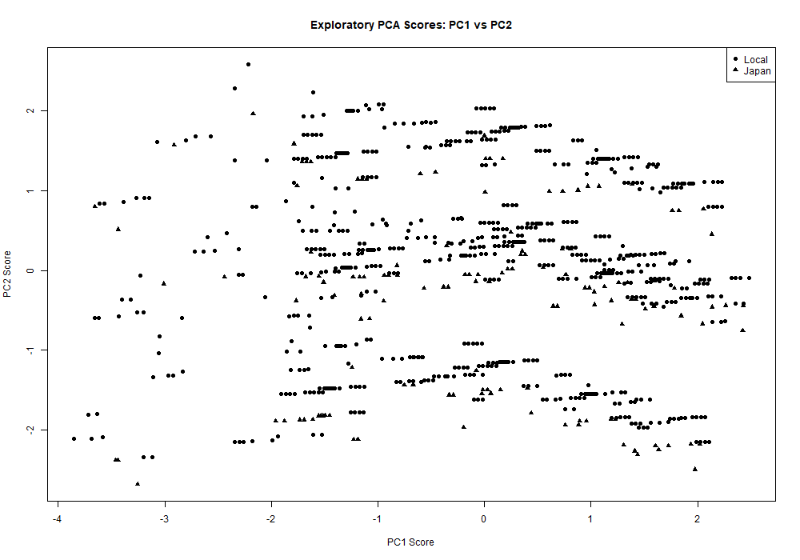

## 15.1 Interpretation

This score plot is exploratory only.

It should **not** be interpreted as evidence that Local and Japan transactions form causal or naturally independent market clusters.

The Japan category is already known to be structurally concentrated in one buyer and within the current Main Dealer regime.

# 16 15. Principal Component Regression

PCA itself is unsupervised.

It identifies directions that explain predictor variation, not necessarily directions that best explain **Quantity**.

To assess potential predictive value, Principal Component Regression (PCR) was tested.

PCR first transforms the predictor space using PCA and then uses selected principal components as predictors in a regression model.

The same chronological test set from Task 5 was used.

# 17 16. Why PCA Can Lose Predictive Information

The first principal components explain the greatest variation in the **predictors**.

However, predictor variance is not the same as predictive relevance.

A low-variance principal component could still contain information strongly associated with Quantity.

This is exactly why the PCR models are evaluated against the existing Reduced MLR rather than assuming that fewer components must improve prediction.

# 18 17. PCR Holdout Results

```r
pcr_comparison = read.csv(
  "08_Model_Results/R/Task7_PCR_Performance_Comparison.csv",
  stringsAsFactors = FALSE
)

kable(
  pcr_comparison,
  digits = 4,
  caption = "PCA/PCR Holdout Performance Comparison"
)
```

PCA/PCR Holdout Performance Comparison

| Model | Components | Test_MAE | Test_RMSE | Test_R2 |
| --- | --- | --- | --- | --- |
| Reduced MLR - Task 5 | NA | 116.8403 | 137.9482 | 0.3987 |
| PCR - 95% Variance (19 PCs) | 19 | 118.1074 | 139.6632 | 0.3837 |
| PCR - All PCs (22 PCs) | 22 | 118.1498 | 140.1878 | 0.3790 |
| PCR - 90% Variance (17 PCs) | 17 | 133.4457 | 166.1572 | 0.1277 |
| PCR - 80% Variance (15 PCs) | 15 | 135.3308 | 169.0430 | 0.0971 |
| Training Mean Baseline | NA | 137.0608 | 178.3421 | -0.0050 |

The main PCR results are approximately:

| PCR model | Components | Test RMSE | Test R-squared |
| --- | --- | --- | --- |
| 80% variance | 15 | 169.04 | 0.0971 |
| 90% variance | 17 | 166.16 | 0.1277 |
| 95% variance | 19 | 139.66 | 0.3837 |
| All PCs | 22 | 140.19 | 0.3790 |

The aggressive dimensionality reductions perform poorly.

This shows that removing components purely because they explain less predictor variance can remove information that is still useful for predicting Quantity.

# 19 18. Comparison with the Task 5 Reduced MLR

The Task 5 Reduced MLR produced:

- MAE ≈ **116.84**
- RMSE ≈ **137.95**
- R-squared ≈ **0.3987**

The strongest PCR specification, using 19 components, produced:

- MAE ≈ **118.11**
- RMSE ≈ **139.66**
- R-squared ≈ **0.3837**

Therefore:

$$PCR\ RMSE - MLR\ RMSE
\approx 1.715$$

The best PCR RMSE is approximately **1.24% higher** than the Reduced MLR RMSE.

Thus PCA-based regression does not improve future holdout prediction.

# 20 19. PCR vs MLR Chart

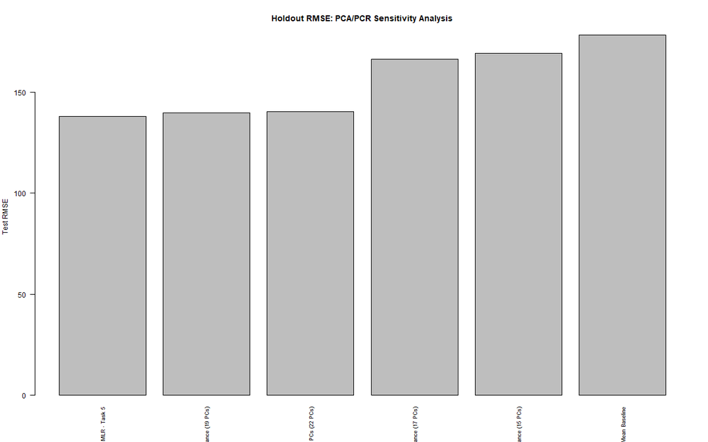

## 20.1 Interpretation

The chart confirms that the Reduced MLR achieves the lowest holdout RMSE among the models being compared here.

The 95% PCR model comes relatively close, but it requires 19 abstract components.

Therefore PCA produces:

- no predictive improvement;
- only limited dimensionality reduction;
- lower interpretability.

# 21 20. Overall PCA Applicability Assessment

```r
pca_applicability = read.csv(
  "08_Model_Results/R/Task7_PCA_Applicability_Assessment.csv",
  stringsAsFactors = FALSE
)

kable(
  pca_applicability,
  caption = "Overall PCA Applicability Assessment for Fragceylon"
)
```

Overall PCA Applicability Assessment for Fragceylon

| Evaluation_Area | Assessment | Fragceylon_Reason |
| --- | --- | --- |
| Need for dimensionality reduction | Limited | The Task 5 encoded matrix has 22 predictors for 1599 training observations, so the problem is not high-dimensional in the usual p-near-n sense. |
| Original continuous-variable suitability | Low | Only Time_Trend is a clean continuous primary predictor after excluding the response, leakage variables, identifiers and business-rule variables. |
| Categorical predictor issue | Important limitation | Important predictors such as Product, Market, Month and Day are categorical and require dummy encoding before ordinary PCA. |
| Target leakage risk | Must be controlled | Quantity and Total Value must not enter predictor PCA because Quantity is the response and Total Value contains Quantity. |
| Scaling requirement | Required | Encoded dummy variables and Time_Trend have different scales, so centering and scaling are necessary. |
| Interpretability | Reduced by PCA | Principal components combine several original variables, making management interpretation harder than the Reduced MLR. |
| Potential multicollinearity benefit | Possible | PCA can transform correlated encoded predictors into orthogonal components, but simpler model reduction already solved the severe Task 5 VIF problem. |
| Expected predictive benefit | Must be evaluated empirically | The best exploratory PCR holdout RMSE is 139.6632 compared with 137.9482 for the Reduced MLR. |
| Business usability | Lower than direct interpretable predictors | Management can interpret Product, Market and Day effects more directly than abstract principal components. |
| Future usefulness | Potentially high with richer high-dimensional numeric data | PCA could become more useful if future data include many correlated continuous marketing, customer, web, inventory and product-attribute measures. |

# 22 21. Potential Advantages of PCA

Although PCA is not recommended for the current Fragceylon dataset, it has genuine potential advantages in appropriate settings.

## 22.1 21.1 Reduced dimensionality

When many correlated numerical predictors exist, PCA can represent most of their information using fewer components.

## 22.2 21.2 Orthogonal components

Principal components are uncorrelated by construction.

This can help when severe multicollinearity creates unstable regression coefficients.

## 22.3 21.3 Computational simplification

High-dimensional models may become faster and simpler after reducing hundreds of predictors to a smaller number of components.

## 22.4 21.4 Noise reduction

Components explaining very little variation can sometimes represent noise rather than useful structure.

However, this is not guaranteed, especially for prediction.

# 23 22. Limitations of PCA for Fragceylon

## 23.1 22.1 Most important variables are categorical

Product, Market, Month and Day of Week are business categories.

Standard PCA is naturally designed for numerical variables.

Dummy encoding makes PCA technically possible but changes the interpretation of the resulting components.

## 23.2 22.2 Reduced interpretability

The Task 5 Reduced MLR directly relates demand to:

- Product;
- Export Market;
- Day of Week.

PCA replaces these direct variables with combinations such as PC1, PC2 and PC3.

This makes it harder to explain results to managers.

## 23.3 22.3 Limited dimensionality reduction

Nineteen components are required to preserve 95% of predictor variance from only 22 original encoded predictors.

This is not a major reduction.

## 23.4 22.4 No predictive improvement

The best PCR model performs slightly worse than the Reduced MLR.

## 23.5 22.5 PCA ignores the response when extracting components

PCA maximizes predictor variance, not predictive power for Quantity.

Important low-variance predictive information can therefore be discarded.

## 23.6 22.6 Scaling affects results

Variables must be standardized when they are measured on different numerical scales.

Different scaling choices can change PCA results.

# 24 23. Effect of PCA on Predictive Modelling

For Fragceylon, PCA has both theoretical and practical consequences for modelling.

### 24.0.1 Possible positive effect

PCA can remove multicollinearity because the components are orthogonal.

### 24.0.2 Current practical result

The Task 5 Reduced MLR had already solved the severe multicollinearity problem through model simplification.

Its maximum VIF was low.

Therefore, PCA is not required merely to address multicollinearity.

### 24.0.3 Predictive result

PCR did not improve holdout RMSE.

Thus PCA adds complexity without delivering a corresponding predictive gain.

# 25 24. Situations Where PCA Should Be Used

PCA could be useful for Fragceylon in the future if the company begins collecting a much richer set of correlated continuous measures.

Examples include:

- advertising spend by campaign;
- website visits;
- product-page views;
- click-through rates;
- conversion rates;
- customer engagement scores;
- customer rating dimensions;
- repeat-purchase indicators;
- inventory measures;
- delivery-time measures;
- product/fragrance attribute scores;
- promotion intensity metrics;
- supplier performance measurements;
- customer behavioural scores.

If these variables become numerous and strongly correlated, PCA could become a useful exploratory and modelling tool.

# 26 25. Situations Where PCA Should Not Be Used

PCA should generally not be used when:

- there are only a few predictors;
- most predictors are categorical;
- original-variable interpretation is essential;
- predictors already have low multicollinearity;
- dimensionality reduction is minimal;
- principal components do not improve validation performance;
- variables include target leakage;
- scaling or coding decisions make components difficult to justify.

The current Fragceylon dataset matches several of these conditions.

# 27 26. Alternatives to PCA for the Current Dataset

For the current problem, more suitable approaches include:

## 27.1 Model simplification

The Reduced MLR achieved strong performance while retaining understandable predictors.

## 27.2 Ridge Regression

Ridge can handle correlated encoded predictors while preserving the original feature structure.

## 27.3 LASSO

LASSO can perform shrinkage and automatic variable selection.

## 27.4 Elastic Net

Elastic Net combines Ridge and LASSO behaviour.

These methods were already evaluated in Task 5 and maintain a more direct connection between predictors and business interpretation than PCA.

# 28 27. Business Interpretation

From a management perspective, the value of a statistical model is not limited to prediction accuracy.

Management also needs to understand:

- which business variables matter;
- how the model can inform decisions;
- what assumptions are involved;
- how results should be interpreted.

A model based on Product, Market and Day of Week is easier to communicate than a model based on 19 principal components.

Therefore, PCA would reduce transparency without providing a clear statistical benefit in the current analysis.

# 29 28. Future Data Collection and PCA

The current conclusion does not mean PCA is permanently irrelevant to Fragceylon.

Future data expansion could change the situation.

For example, Fragceylon could collect:

- multiple product attribute scores;
- customer survey dimensions;
- digital campaign metrics;
- social-media engagement variables;
- inventory-performance metrics;
- supplier/service metrics;
- detailed customer behavioural indicators.

If dozens of correlated continuous variables become available, PCA could then be reconsidered.

# 30 29. Research Literature Support

The assignment requires the Task 7 argument to be supported by research findings.

**No research references are fabricated in this R Markdown file.**

Before final submission, verified papers from the Task 2 literature matrix should be used to support statements about:

- when PCA is useful;
- dimensionality reduction;
- PCA and multicollinearity;
- scaling;
- information loss;
- interpretability;
- PCA before predictive modelling;
- PCR performance;
- PCA with mixed/categorical data;
- PCA use in retail or marketing analytics.

A recommended literature integration style is:

[output not shown]

Research literature should be used to **support the reasoning**, not replace the empirical findings from the Fragceylon dataset.

# 31 30. Task 7 Final Evaluation

The empirical evaluation indicates that PCA is **not currently necessary as the primary dimensionality-reduction or predictive method for Fragceylon**.

The main reasons are:

- only one clean continuous primary predictor is naturally suitable for ordinary PCA;
- important business predictors are categorical;
- the encoded modelling space contains only 22 predictors for 1,599 training observations;
- no pair of encoded predictors has absolute correlation above 0.70;
- 19 principal components are required to retain 95% of predictor variance;
- the best PCR model has a higher holdout RMSE than the Reduced MLR;
- principal components are less interpretable for management.

Therefore, the Task 5 Reduced MLR remains more suitable for the current organizational use case.

PCA should be reconsidered only if future data collection produces a substantially larger set of correlated continuous predictors.

# 32 Appendix A - Explained Variance Table

```r
kable(
  pca_variance,
  digits = 4,
  caption = "Full PCA Explained Variance Table"
)
```

Full PCA Explained Variance Table

| Principal_Component | Eigenvalue | Explained_Variance | Explained_Variance_Percent | Cumulative_Variance | Cumulative_Variance_Percent |
| --- | --- | --- | --- | --- | --- |
| PC1 | 1.6615 | 0.0755 | 7.5523 | 0.0755 | 7.5523 |
| PC2 | 1.4407 | 0.0655 | 6.5486 | 0.1410 | 14.1009 |
| PC3 | 1.3774 | 0.0626 | 6.2607 | 0.2036 | 20.3616 |
| PC4 | 1.3297 | 0.0604 | 6.0443 | 0.2641 | 26.4059 |
| PC5 | 1.2887 | 0.0586 | 5.8579 | 0.3226 | 32.2637 |
| PC6 | 1.2277 | 0.0558 | 5.5805 | 0.3784 | 37.8443 |
| PC7 | 1.2106 | 0.0550 | 5.5029 | 0.4335 | 43.3472 |
| PC8 | 1.1809 | 0.0537 | 5.3678 | 0.4871 | 48.7149 |
| PC9 | 1.1300 | 0.0514 | 5.1361 | 0.5385 | 53.8511 |
| PC10 | 1.0709 | 0.0487 | 4.8679 | 0.5872 | 58.7190 |
| PC11 | 1.0632 | 0.0483 | 4.8329 | 0.6355 | 63.5519 |
| PC12 | 1.0333 | 0.0470 | 4.6968 | 0.6825 | 68.2486 |
| PC13 | 1.0187 | 0.0463 | 4.6304 | 0.7288 | 72.8790 |
| PC14 | 1.0005 | 0.0455 | 4.5478 | 0.7743 | 77.4268 |
| PC15 | 0.9943 | 0.0452 | 4.5195 | 0.8195 | 81.9463 |
| PC16 | 0.9838 | 0.0447 | 4.4718 | 0.8642 | 86.4180 |
| PC17 | 0.9423 | 0.0428 | 4.2833 | 0.9070 | 90.7013 |
| PC18 | 0.9285 | 0.0422 | 4.2206 | 0.9492 | 94.9219 |
| PC19 | 0.6557 | 0.0298 | 2.9806 | 0.9790 | 97.9024 |
| PC20 | 0.2891 | 0.0131 | 1.3142 | 0.9922 | 99.2166 |
| PC21 | 0.1710 | 0.0078 | 0.7772 | 0.9999 | 99.9938 |
| PC22 | 0.0014 | 0.0001 | 0.0062 | 1.0000 | 100.0000 |

# 33 Appendix B - Full PCA Loadings

```r
pca_loadings = read.csv(
  "08_Model_Results/R/Task7_PCA_Loadings.csv",
  stringsAsFactors = FALSE
)

kable(
  pca_loadings,
  digits = 4,
  caption = "Full Exploratory PCA Loading Matrix"
)
```

Full Exploratory PCA Loading Matrix

| Original_Variable | PC1 | PC2 | PC3 | PC4 | PC5 | PC6 | PC7 | PC8 | PC9 | PC10 | PC11 | PC12 | PC13 | PC14 | PC15 | PC16 | PC17 | PC18 | PC19 | PC20 | PC21 | PC22 |
| --- | --- | --- | --- | --- | --- | --- | --- | --- | --- | --- | --- | --- | --- | --- | --- | --- | --- | --- | --- | --- | --- | --- |
| `Product Name`Kennedy | -0.0148 | 0.6401 | 0.1713 | -0.3192 | 0.1659 | 0.1678 | 0.1401 | 0.0660 | 0.0183 | 0.0299 | -0.0832 | 0.0510 | -0.0015 | -0.1264 | 0.0756 | -0.0041 | 0.0071 | 0.0037 | -0.0591 | 0.5852 | -0.0277 | 0.0017 |
| `Product Name`Mesmerose | -0.0696 | -0.7010 | 0.2566 | -0.1693 | 0.0121 | -0.0912 | 0.0244 | 0.0862 | -0.0149 | -0.0060 | -0.0607 | -0.0548 | -0.0594 | -0.0572 | -0.0772 | -0.0078 | -0.0920 | 0.0538 | 0.0170 | 0.5994 | -0.0443 | 0.0008 |
| `Product Name`Secret Ambrosia | 0.0866 | 0.0917 | -0.4211 | 0.5616 | -0.1925 | -0.0764 | -0.1897 | -0.1883 | 0.0234 | -0.0192 | 0.2035 | -0.0119 | 0.0882 | 0.1417 | -0.0246 | 0.0135 | 0.1125 | -0.0268 | 0.0276 | 0.5397 | -0.0202 | 0.0012 |
| `Export Market`Japan | -0.0149 | -0.0987 | -0.0060 | 0.1455 | 0.0814 | 0.2831 | 0.0045 | 0.0104 | -0.1952 | 0.1255 | -0.1391 | 0.4289 | 0.0015 | -0.0594 | 0.0053 | 0.0097 | -0.1751 | -0.7663 | 0.0513 | 0.0235 | 0.0002 | -0.0008 |
| MonthAugust | -0.1351 | -0.0729 | -0.0735 | -0.0041 | 0.0017 | 0.0393 | 0.2371 | 0.0523 | 0.0001 | -0.1372 | -0.0690 | -0.5206 | 0.2513 | -0.0310 | 0.5626 | 0.1412 | 0.2228 | -0.2966 | 0.2700 | 0.0136 | 0.0288 | 0.0616 |
| MonthDecember | 0.0800 | 0.1317 | 0.5435 | 0.3077 | -0.3833 | -0.1237 | 0.0801 | -0.0646 | 0.2623 | 0.0325 | -0.2138 | 0.0490 | 0.0912 | -0.0134 | -0.0742 | 0.1805 | -0.1017 | -0.0084 | 0.1931 | -0.0174 | 0.0106 | 0.4480 |
| MonthFebruary | 0.1597 | -0.0409 | -0.1375 | 0.0647 | 0.1024 | -0.1956 | 0.1983 | -0.0864 | 0.2812 | 0.0959 | -0.1224 | 0.0337 | -0.6042 | -0.1765 | 0.2001 | -0.4376 | 0.2269 | -0.1054 | -0.0182 | 0.0059 | -0.0128 | 0.2428 |
| MonthJanuary | 0.3462 | -0.0383 | -0.3642 | -0.3628 | -0.3051 | 0.1069 | -0.1859 | 0.0677 | -0.3736 | -0.0112 | -0.2510 | 0.0108 | -0.0192 | -0.0701 | -0.0287 | 0.1177 | 0.0598 | 0.0830 | 0.0859 | 0.0229 | -0.0038 | 0.4792 |
| MonthJuly | -0.0877 | 0.0656 | -0.0489 | 0.1259 | 0.0354 | 0.1389 | -0.2041 | -0.1289 | -0.0842 | 0.0450 | 0.1565 | -0.3145 | -0.2963 | -0.4461 | 0.1130 | 0.0582 | -0.6424 | 0.0882 | 0.1838 | -0.0138 | -0.0144 | 0.0296 |
| MonthJune | -0.1926 | 0.0239 | -0.0393 | -0.0079 | 0.0784 | 0.2032 | -0.0341 | 0.0712 | 0.0110 | 0.2131 | -0.1627 | 0.0101 | -0.3418 | 0.7273 | 0.1379 | 0.0635 | -0.1546 | 0.1548 | 0.3403 | 0.0353 | 0.0144 | 0.0300 |
| MonthMarch | 0.3675 | -0.1179 | 0.1294 | 0.0118 | 0.3341 | 0.2159 | 0.1710 | -0.0848 | -0.0279 | 0.1847 | 0.5681 | 0.0383 | 0.1696 | 0.1589 | 0.1738 | 0.0089 | -0.0694 | 0.0759 | -0.1264 | -0.0134 | 0.0046 | 0.4115 |
| MonthMay | -0.3172 | -0.0848 | -0.1051 | -0.0806 | -0.0232 | 0.1100 | 0.0553 | -0.1915 | 0.0753 | 0.1380 | 0.1525 | 0.4904 | 0.1558 | -0.3130 | 0.1289 | -0.0003 | 0.2225 | 0.2969 | 0.5065 | -0.0135 | -0.0141 | 0.0203 |
| MonthNovember | -0.0467 | 0.0390 | -0.0369 | -0.0289 | 0.3488 | -0.1207 | -0.1863 | 0.0907 | 0.1097 | -0.7636 | 0.0407 | 0.1466 | 0.0519 | 0.1007 | -0.0860 | -0.1472 | -0.1347 | -0.0577 | 0.2499 | 0.0081 | -0.0042 | 0.2661 |
| MonthOctober | -0.0795 | 0.0585 | -0.0325 | -0.0342 | 0.1722 | -0.1418 | -0.0118 | -0.1544 | -0.1285 | 0.3408 | -0.1646 | -0.2716 | 0.3964 | 0.0523 | -0.3194 | -0.5786 | -0.1035 | -0.0558 | 0.2331 | -0.0012 | 0.0148 | 0.1254 |
| MonthSeptember | -0.1300 | 0.0787 | -0.0438 | -0.1104 | 0.0005 | -0.1022 | 0.2085 | 0.1500 | -0.0455 | 0.0712 | 0.4079 | -0.2008 | -0.2821 | -0.0278 | -0.5565 | 0.2777 | 0.2235 | -0.2572 | 0.2806 | -0.0062 | 0.0219 | 0.1005 |
| Day_of_WeekFriday | 0.1006 | -0.0973 | -0.1001 | -0.0660 | 0.3305 | 0.2295 | -0.0898 | -0.5017 | 0.3391 | 0.0036 | -0.2939 | -0.1240 | 0.0144 | -0.0442 | -0.2233 | 0.3354 | 0.1047 | -0.0108 | -0.0451 | 0.0133 | 0.3870 | -0.0002 |
| Day_of_WeekSaturday | -0.1239 | -0.0236 | -0.1315 | -0.0201 | -0.3350 | 0.1842 | 0.6109 | -0.1922 | -0.1237 | -0.2860 | 0.0496 | 0.0433 | -0.0187 | 0.0885 | -0.0931 | -0.2079 | -0.2449 | 0.0756 | -0.1078 | 0.0303 | 0.4128 | 0.0004 |
| Day_of_WeekSunday | 0.1104 | 0.0078 | -0.0614 | 0.3847 | 0.3456 | -0.1522 | 0.1858 | 0.4807 | -0.2514 | 0.1007 | -0.2180 | 0.0809 | 0.0265 | -0.1736 | -0.0111 | 0.1401 | 0.0089 | 0.2432 | 0.0801 | 0.0255 | 0.4283 | -0.0008 |
| Day_of_WeekThursday | 0.0286 | 0.0007 | -0.2404 | -0.2784 | -0.1795 | -0.2113 | -0.1424 | 0.3351 | 0.5242 | 0.2110 | 0.1682 | 0.0873 | 0.1700 | 0.0234 | 0.1041 | -0.0065 | -0.2822 | -0.1611 | -0.0009 | 0.0301 | 0.3903 | -0.0010 |
| Day_of_WeekTuesday | -0.0336 | -0.0165 | 0.2812 | 0.0896 | -0.1670 | 0.4909 | -0.3969 | 0.2134 | -0.0113 | -0.0631 | 0.1454 | -0.1361 | -0.0928 | -0.0598 | -0.0243 | -0.3405 | 0.3273 | -0.0008 | 0.0308 | 0.0031 | 0.3986 | 0.0000 |
| Day_of_WeekWednesday | -0.0874 | 0.0858 | 0.2348 | -0.1471 | 0.0039 | -0.5008 | -0.2282 | -0.3614 | -0.4007 | 0.0262 | 0.1446 | 0.0951 | -0.1242 | 0.1010 | 0.2388 | 0.0604 | 0.0606 | -0.1156 | -0.0075 | 0.0268 | 0.4235 | 0.0010 |
| Time_Trend | 0.6813 | 0.0104 | 0.1264 | -0.0761 | -0.0786 | -0.0170 | 0.0899 | -0.0736 | 0.0052 | -0.0883 | 0.0373 | 0.0091 | -0.0220 | 0.0288 | -0.0016 | -0.0758 | -0.0445 | -0.0225 | 0.4860 | 0.0077 | 0.0118 | -0.4887 |

# 34 Appendix C - Task 7 Output Files

```r
task7_results = list.files(
  "08_Model_Results/R",
  pattern = "^Task7",
  full.names = FALSE
)

task7_results
```

```
##  [1] "Task7_Numeric_Variable_Audit.csv"
##  [2] "Task7_PC1_Loadings_Ranked.csv"
##  [3] "Task7_PC2_Loadings_Ranked.csv"
##  [4] "Task7_PCA_Applicability_Assessment.csv"
##  [5] "Task7_PCA_Explained_Variance.csv"
##  [6] "Task7_PCA_Loadings.csv"
##  [7] "Task7_PCA_Predictor_Matrix_Audit.csv"
##  [8] "Task7_PCA_Variance_Thresholds.csv"
##  [9] "Task7_PCR_Performance_Comparison.csv"
## [10] "Task7_Report_Ready_Summary.txt"
## [11] "Task7_Variable_Suitability_Audit.csv"
```